# NLP2

```
• DOMAIN: Digital content and entertainment industry
• CONTEXT: The objective of this project is to build a text classification model that analyses the customer's
sentiments based on their reviews in the IMDB database. The model uses a complex deep learning model to build
an embedding layer followed by a classification algorithm to analyse the sentiment of the customers.
• DATA DESCRIPTION: The Dataset of 50,000 movie reviews from IMDB, labelled by sentiment (positive/negative).
Reviews have been preprocessed, and each review is encoded as a sequence of word indexes (integers). For
convenience, the words are indexed by their frequency in the dataset, meaning the for that has index 1 is the most
frequent word. Use the first 20 words from each review to speed up training, using a max vocabulary size of
10,000. As a convention, "0" does not stand for a specific word, but instead is used to encode any unknown word.
• PROJECT OBJECTIVE: To Build a sequential NLP classifier which can use input text parameters to determine the
customer sentiments.
```

- Steps and tasks: [ Total Score: 30 Marks]

#### 1. Import and analyse the data set. [5 Marks]

```python
import tensorflow as tf
import tensorflow.keras.datasets.imdb as imdb
from tensorflow import keras
from tensorflow.keras import layers
import numpy as np
import pandas as pd
from tensorflow.keras.callbacks import EarlyStopping, ReduceLROnPlateau, ModelCheckpoint
from tensorflow.keras.optimizers import Adam
import seaborn as sns
from sklearn.metrics import confusion_matrix
import matplotlib.pyplot as plt
from sklearn.model_selection import train_test_split
import matplotlib.pyplot as plt
import re
import gensim.downloader as api
import numpy as np
from tensorflow.keras.layers import Embedding, LSTM, Dense, Bidirectional
```

```python
vocab_size =10000
max_word_len =20
(x_train, y_train), (x_test, y_test) = imdb.load_data(num_words =vocab_size)
```

```python
print("Total Number of Sentence in training  ", len(x_train))
print("Total Number of Sentence in testing  ", len(x_test))
```

```
Total Number of Sentence in training   25000
Total Number of Sentence in testing   25000
```

```python
# Get the sentence whose length is less than passing length
def get_sent_index(dataset, word_length):
  sent_with_less_words= list()
  for  idx, sent in enumerate(dataset):
    length = len(sent)
    if length < word_length:
      sent_with_less_words.append(idx)
  return sent_with_less_words
```

```python
# Get the Training/Test sentences whose length of words are less than 20 words
train_indx = get_sent_index(x_train, 20)
test_indx = get_sent_index(x_test, 20)
```

```python
#Get 5 sentences from train dataset. this dataset contains sentences in number
x_train[train_indx[0:5]]
```

```
array([list([1, 6, 675, 7, 300, 127, 24, 895, 8, 2623, 89, 753, 2279, 5, 6866, 78, 14, 20, 9]),
       list([1, 2, 390, 1351, 9, 4, 118, 390, 7, 2, 45, 61, 514, 390, 7, 2]),
       list([1, 13, 586, 851, 14, 31, 60, 23, 2863, 2364, 314]),
       list([1, 14, 20, 9, 394, 21, 12, 47, 49, 52, 302]),
       list([1, 13, 92, 124, 138, 13, 40, 14, 20, 38, 73, 21, 13, 115, 79, 1458, 7, 149, 12])],
      dtype=object)
```

#### 2. Perform relevant sequence adding on the data. [5 Marks]

```python
X_train_pad = tf.keras.preprocessing.sequence.pad_sequences(x_train, maxlen = max_word_len, padding='pre', truncating='pre')
X_test_pad = tf.keras.preprocessing.sequence.pad_sequences(x_test, maxlen = max_word_len, padding='pre', truncating='pre')
```

```python
indx = np.random.choice(train_indx)
print("Before Padding training first sentence, ", x_train[indx])
print("After padding training first sentence , ", X_train_pad[indx])
```

```
Before Padding training first sentence,  [1, 2, 4, 2, 127, 6, 117, 2, 5, 6, 20, 91, 3939]
After padding training first sentence ,  [   0    0    0    0    0    0    0    1    2    4    2  127    6  117
    2    5    6   20   91 3939]
```

```python
indx = np.random.choice(test_indx)
print("Before Padding testing first sentence, ", x_test[indx])
print("After padding testing first sentence , ", X_test_pad[indx])
```

```
Before Padding testing first sentence,  [1, 6, 6070, 22, 15, 434, 941, 129, 692, 1022, 5805, 9, 1429, 5, 8224, 8, 106]
After padding testing first sentence ,  [   0    0    0    1    6 6070   22   15  434  941  129  692 1022 5805
    9 1429    5 8224    8  106]
```

#### 3. Perform following data analysis: [5 Marks]

• Print shape of features and labels

```python
print("Shape of X train data " , X_train_pad.shape)
print("Shape of X test data " , X_test_pad.shape)
```

```
Shape of X train data  (25000, 20)
Shape of X test data  (25000, 20)
```

```python
print("Shape of y train data " , y_train.shape)
print("Shape of y test data " , y_test.shape)
```

```
Shape of y train data  (25000,)
Shape of y test data  (25000,)
```

• Print value of any one feature and it's label

```python
randm = np.random.randint(0, len(X_train_pad))
print('random index : ', randm)
print("X ->", X_train_pad[randm])
print("y ->", y_train[randm])
```

```
random index :  11432
X -> [9696    2    2 1250   19 4098    2  289 3815 1594 6023    4   86  289
  102 5444    5   19  318  944]
y -> 0
```

#### 4. Decode the feature value to get original sentence [5 Marks]

```python
word_index = imdb.get_word_index()
```

```
Downloading data from https://storage.googleapis.com/tensorflow/tf-keras-datasets/imdb_word_index.json
```

```python
reverse_word_map = dict(map(reversed, word_index.items()))
```

```python
print(reverse_word_map)
```

[output not shown]

```python
def num_2_sent(sentence):
  words =''
  for i in range(len(sentence)):
    num = sentence[i]
    if num in  reverse_word_map:
      word = reverse_word_map[num]
      words = words + word + " ";
    else:
      words = words + 'None' + " ";
  return words
```

```python
randm = np.random.randint(0, len(X_train_pad))
print('random index : ', randm)
print("X_train ->", X_train_pad[randm])
print("number to sentence : ", num_2_sent(X_train_pad[randm]))
```

```
random index :  1504
X_train -> [  11    4 4277   14    9    6   66   78   22   19   78 1296    5   78
  156  407    6  437    7  278]
number to sentence :  this of blew as it is had do you film do twists to do before itself is hope br sense
```

1. Design, train, tune and test a sequential model. [5 Marks]

```python
tf.keras.backend.clear_session()
model = tf.keras.Sequential()
model.add(tf.keras.layers.Embedding(vocab_size, 25, trainable=True, input_length=max_word_len))
model.add(tf.keras.layers.BatchNormalization())
model.add(tf.keras.layers.SpatialDropout1D(0.4))
model.add(tf.keras.layers.Bidirectional(tf.keras.layers.LSTM(units=64, dropout=0.4, recurrent_dropout=0.2)))
model.add(tf.keras.layers.Dense(1, activation='sigmoid'))
model.compile(Adam(), "binary_crossentropy", metrics=["accuracy"])
```

[output not shown]

```python
model.summary()
```

```
Model: "sequential"
_________________________________________________________________
 Layer (type)                Output Shape              Param #
=================================================================
 embedding (Embedding)       (None, 20, 25)            250000

 batch_normalization (BatchN  (None, 20, 25)           100
 ormalization)

 spatial_dropout1d (SpatialD  (None, 20, 25)           0
 ropout1D)

 bidirectional (Bidirectiona  (None, 128)              46080
 l)

 dense (Dense)               (None, 1)                 129

=================================================================
Total params: 296,309
Trainable params: 296,259
Non-trainable params: 50
_________________________________________________________________
```

```python
EPOCHES = 50
BATCH_SIZE = 128
stop_early = EarlyStopping(monitor='val_loss', mode='min', patience=5)
reduce_lr = ReduceLROnPlateau(monitor='val_loss',factor=0.1,patience=3,min_lr=0.00001,model='auto')
model_checkpoint_callback = tf.keras.callbacks.ModelCheckpoint(
    filepath="best_model.hdf5",save_weights_only=True,monitor='val_accuracy',mode='max',save_best_only=True)
history = model.fit(X_train_pad, y_train, batch_size = BATCH_SIZE, epochs = EPOCHES, validation_data=(X_test_pad, y_test), callbacks=[reduce_lr, stop_early, model_checkpoint_callback])
```

```python
loss = history.history['loss']
accuracy = history.history['accuracy']
val_loss = history.history['val_loss']
val_accuracy = history.history['val_accuracy']
```

Training loss vs Validation loss

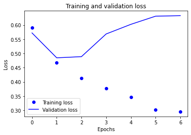

```python
plt.plot(loss, 'bo', label='Training loss')
plt.plot(val_loss, 'b', label='Validation loss')
plt.title('Training and validation loss')
plt.xlabel('Epochs')
plt.ylabel('Loss')
plt.legend()
plt.show()
```

Observation:

- Training loss is less than Validation loss
- Model is overfitting.

Training Accuracy vs Validation Accuracy

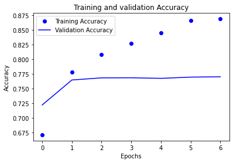

```python
plt.plot(accuracy, 'bo', label='Training Accuracy')
plt.plot(val_accuracy, 'b', label='Validation Accuracy')
plt.title('Training and validation Accuracy')
plt.xlabel('Epochs')
plt.ylabel('Accuracy')
plt.legend()
plt.show()
```

Observation:

- Accuracy of training is more than validation
- Model is overfitting

#### Model Score

```python
_, accuracy = model.evaluate(X_test_pad, y_test)
print("Accuracy in testing score is ", accuracy)
```

```
Accuracy in testing score is  0.7702400088310242
```

#### 6. Use the designed model to print the prediction on any one sample. [5 Marks]

```python
index = np.random.randint(0, len(X_test_pad))
input = X_test_pad[index]
input_dim = np.expand_dims(input, axis=0)
pred = model.predict(input_dim)
print("pred : ", np.argmax(pred))
print("actual : ", y_test[index])
```

```
pred :  0
actual :  0
```

```python
def print_confusion_matrix(testY, predicted_test_y):
    mat = confusion_matrix(testY, predicted_test_y)

    plt.figure(figsize=(4, 4))
    sns.set()
    sns.heatmap(mat.T, square=True, annot=True, fmt='d', cbar=False,
                xticklabels=np.unique(testY),
                yticklabels=np.unique(testY))

    plt.xlabel('true label')
    plt.ylabel('predicted label')
    plt.show()
```

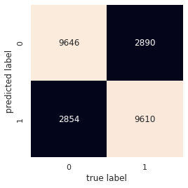

```python
#Calculate accuracy on Test Dataset
predicted_test_y = model.predict(X_test_pad)
predicted_test_y_binary = predicted_test_y >= 0.5

print_confusion_matrix(y_test, predicted_test_y_binary)
```

```
# • DOMAIN: Social media analytics
• CONTEXT: Past studies in Sarcasm Detection mostly make use of Twitter datasets collected using hashtag based
supervision but such datasets are noisy in terms of labels and language. Furthermore, many tweets are replies to
other tweets and detecting sarcasm in these requires the availability of contextual tweets.In this hands-on project,
the goal is to build a model to detect whether a sentence is sarcastic or not, using Bidirectional LSTMs.
• DATA DESCRIPTION:
The dataset is collected from two news websites, theonion.com and huffingtonpost.com.
This new dataset has the following advantages over the existing Twitter datasets:
Since news headlines are written by professionals in a formal manner, there are no spelling mistakes and informal usage. This
reduces the sparsity and also increases the chance of finding pre-trained embeddings.
Furthermore, since the sole purpose of TheOnion is to publish sarcastic news, we get high-quality labels with much less noise as
compared to Twitter datasets.
Unlike tweets that reply to other tweets, the news headlines obtained are self-contained. This would help us in teasing apart the
real sarcastic elements
Content: Each record consists of three attributes:
is_sarcastic: 1 if the record is sarcastic otherwise 0
headline: the headline of the news article
article_link: link to the original news article. Useful in collecting supplementary data
Reference: https://github.com/rishabhmisra/News-Headlines-Dataset-For-Sarcasm-Detection
```

#### 1. Read and explore the data [3 Marks]

```python
df =  pd.read_json('https://raw.githubusercontent.com/rishabhmisra/News-Headlines-Dataset-For-Sarcasm-Detection/master/Sarcasm_Headlines_Dataset.json', lines=True)
```

- Read the dataset

```python
df.head()
```

|  | is_sarcastic | headline | article_link |
| --- | --- | --- | --- |
| 0 | 1 | thirtysomething scientists unveil doomsday clo... | https://www.theonion.com/thirtysomething-scien... |
| 1 | 0 | dem rep. totally nails why congress is falling... | https://www.huffingtonpost.com/entry/donna-edw... |
| 2 | 0 | eat your veggies: 9 deliciously different recipes | https://www.huffingtonpost.com/entry/eat-your-... |
| 3 | 1 | inclement weather prevents liar from getting t... | https://local.theonion.com/inclement-weather-p... |
| 4 | 1 | mother comes pretty close to using word 'strea... | https://www.theonion.com/mother-comes-pretty-c... |

- Find the count of sarcastic and non sarcastic comments

```python
df.is_sarcastic.value_counts(normalize=True)
```

```
0    0.523603
1    0.476397
Name: is_sarcastic, dtype: float64
```

Observation :

- There are 52% non sarcastic comments and 48% sarcastic
- Almost the dataset is balanced
- Check for null value

```python
df.isna().sum()
```

```
is_sarcastic    0
headline        0
article_link    0
dtype: int64
```

There is no null values in the dataset

- Check for duplicate values

```python
df.duplicated().sum()
```

```
2
```

- There are two records which are duplicate. Lets remove the duplicate records

```python
df.drop_duplicates(inplace=True, ignore_index=True)
```

- Duplicate records has been removed

```python
df['headline'] = df['headline'].apply(lambda x: x.lower())
df['headline'] = df['headline'].apply((lambda x: re.sub('[^a-zA-z0-9\s]','',x)))
```

#### 2. Retain relevant columns [3 Marks]

- Removing the article link, that only contains the content where it was feched from

```python
df.drop('article_link', axis=1,inplace=True)
df.head()
```

|  | is_sarcastic | headline |
| --- | --- | --- |
| 0 | 1 | thirtysomething scientists unveil doomsday clo... |
| 1 | 0 | dem rep totally nails why congress is falling ... |
| 2 | 0 | eat your veggies 9 deliciously different recipes |
| 3 | 1 | inclement weather prevents liar from getting t... |
| 4 | 1 | mother comes pretty close to using word stream... |

#### 3. Get length of each sentence [3 Marks]

```python
df['length']= df['headline'].apply(lambda sen : len(sen))
```

```python
df.head()
```

|  | is_sarcastic | headline | length |
| --- | --- | --- | --- |
| 0 | 1 | thirtysomething scientists unveil doomsday clo... | 61 |
| 1 | 0 | dem rep totally nails why congress is falling ... | 77 |
| 2 | 0 | eat your veggies 9 deliciously different recipes | 48 |
| 3 | 1 | inclement weather prevents liar from getting t... | 52 |
| 4 | 1 | mother comes pretty close to using word stream... | 59 |

#### 4. Define parameters [3 Marks]

```python
max_features = 10000
embedding =200
maxlen = 25
X = df['headline']
y = df['is_sarcastic']
```

### 5. Get indices for words [3 Marks]

```python
tokenizer = tf.keras.preprocessing.text.Tokenizer(num_words=max_features)
tokenizer.fit_on_texts(list(X))
X_token = tokenizer.texts_to_sequences(X)
```

```python
X[0]
```

```
'thirtysomething scientists unveil doomsday clock of hair loss'
```

```python
X_token[0]
```

```
[336, 3105, 6322, 2318, 2, 671, 1138]
```

```python
X_token_pad = tf.keras.preprocessing.sequence.pad_sequences(X_token, maxlen = maxlen)
```

#### 6. Create features and labels [3 Marks]

```python
X_train, X_test, Y_train, Y_test = train_test_split(X_token_pad,y, test_size = 0.20, random_state = 42)
print(X_train.shape,Y_train.shape)
print(X_test.shape,Y_test.shape)
```

```
(22893, 25) (22893,)
(5724, 25) (5724,)
```

#### 7. Get vocabulary size [3 Marks]

```python
print(tokenizer.num_words)
```

```
10000
```

```python
print(tokenizer.index_word)
```

[output not shown]

#### 8. Create a weight matrix using GloVe embeddings [3 Marks]

```python
from google.colab import drive
drive.mount('/content/drive')
```

```python
#Copy in current directory of google colab
!cp '/content/drive/My Drive/NLP/Assignment_2/glove.6B.200d.txt' .
```

```python
embeddings_index = {}
f = open('./glove.6B.200d.txt',encoding='utf-8')
for line in f:
    values = line.split()
    word = values[0]
    coefs = np.asarray(values[1:], dtype='float32')
    embeddings_index[word] = coefs
f.close()

print('Found %s word vectors.' % len(embeddings_index))
```

```
Found 400000 word vectors.
```

```python
all_embs = np.stack(embeddings_index.values())
emb_mean,emb_std = all_embs.mean(), all_embs.std()
embed_size = all_embs.shape[1]

word_index = tokenizer.word_index
nb_words = min(max_features, len(word_index))
embedding_matrix = embedding_matrix = np.random.normal(emb_mean, emb_std, (nb_words, embed_size))
for word, i in word_index.items():
    if i >= max_features: continue
    embedding_vector = embeddings_index.get(word)
    if embedding_vector is not None: embedding_matrix[i] = embedding_vector
```

```python
embedding_matrix.shape
```

```
(10000, 200)
```

### 9. Define and compile a Bidirectional LSTM model. [3 Marks]

```python
tf.keras.backend.clear_session()
model = tf.keras.Sequential()
model.add(Embedding(max_features, output_dim=embedding, weights=[embedding_matrix], input_length=maxlen, trainable=False))
model.add(tf.keras.layers.Bidirectional(LSTM(units=128 , return_sequences = True , recurrent_dropout = 0.25 , dropout = 0.25)))
model.add(tf.keras.layers.Bidirectional(LSTM(units=64 , recurrent_dropout = 0.1 , dropout = 0.1)))
model.add(Dense(units = 32 , activation = 'relu'))
model.add(Dense(1, activation='sigmoid'))
model.compile(optimizer=keras.optimizers.Adam(lr = 0.01), loss='binary_crossentropy', metrics=['accuracy'])
```

[output not shown]

```python
model.summary()
```

```
Model: "sequential"
_________________________________________________________________
 Layer (type)                Output Shape              Param #
=================================================================
 embedding (Embedding)       (None, 25, 200)           2000000

 bidirectional (Bidirectiona  (None, 25, 256)          336896
 l)

 bidirectional_1 (Bidirectio  (None, 128)              164352
 nal)

 dense (Dense)               (None, 32)                4128

 dense_1 (Dense)             (None, 1)                 33

=================================================================
Total params: 2,505,409
Trainable params: 505,409
Non-trainable params: 2,000,000
_________________________________________________________________
```

```python
batch_size =256
epochs =50
stop_early = EarlyStopping(monitor='val_loss', mode='min', patience=5)
reduce_lr = ReduceLROnPlateau(monitor='val_loss',factor=0.1,patience=3,min_lr=0.00001,model='auto')
model_checkpoint_callback = tf.keras.callbacks.ModelCheckpoint(
    filepath="best_model_Q2.hdf5",save_weights_only=True,monitor='val_accuracy',mode='max',save_best_only=True)
history = model.fit(X_train, Y_train, batch_size=batch_size, epochs=epochs, validation_data=(X_test, Y_test), callbacks = [stop_early, reduce_lr, model_checkpoint_callback])
```

```python
loss = history.history['loss']
accuracy = history.history['accuracy']
val_loss = history.history['val_loss']
val_accuracy = history.history['val_accuracy']
```

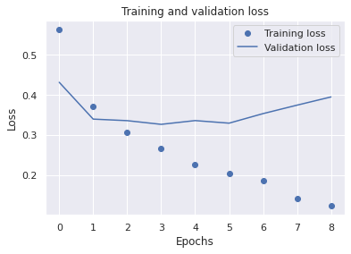

```python
plt.plot(loss, 'bo', label='Training loss')
plt.plot(val_loss, 'b', label='Validation loss')
plt.title('Training and validation loss')
plt.xlabel('Epochs')
plt.ylabel('Loss')
plt.legend()
plt.show()
```

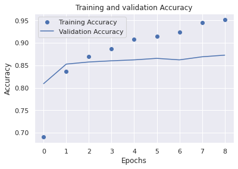

```python
plt.plot(accuracy, 'bo', label='Training Accuracy')
plt.plot(val_accuracy, 'b', label='Validation Accuracy')
plt.title('Training and validation Accuracy')
plt.xlabel('Epochs')
plt.ylabel('Accuracy')
plt.legend()
plt.show()
```

#### 10. Fit the model and check the validation accuracy [3 Marks]

```python
#Calculate accuracy on Test Dataset
_, accuracy = model.evaluate(X_test, Y_test)
print("Accuracy in testing score is ", accuracy)
```

```
Accuracy in testing score is  0.8726415038108826
```

```python
mapping = {1: "Sarcastic", 0: " not Sarcastic"}
```

```python
index = np.random.randint(0, len(X_test))
input = X_test[index]
input_dim = np.expand_dims(input, axis=0)
pred = model.predict(input_dim)
print("predicted : ", mapping[np.argmax(pred)])
print("actual : ", mapping[y_test[index]])
```

```
predicted :   not Sarcastic
actual :   not Sarcastic
```

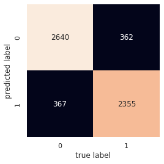

```python
predicted_test_y = model.predict(X_test)
predicted_test_y_binary = predicted_test_y >= 0.5

print_confusion_matrix(Y_test, predicted_test_y_binary)
```